# DAR CW 2

# 13191103

## 1. Bayesian networks and naïve Bayes classifiers.

### a) Given a training dataset including 10 observations and a Bayesian network indicating the relationships between 3 features (i.e. Income, Student and Credit Rate) and the class attribute (i.e. Buy Computer), please create the conditional probability tables by hand.

P(Income=High|Buy=Yes) = 5/12 = 0.42

P(Income=Low|Buy=Yes) = 7/12 = 0.58

P(Income=High|Buy=No) = 7/18 = 0.39

P(Income=Low|Buy=No) = 11/18 = 0.61

P(Student=TRUE|Buy=Yes) = 6/12 = 0.5

P(Student=FALSE|Buy=Yes) = 6/12 = 0.5

P(Student=TRUE|Buy=No) = 12/18 = 0.67

P(Student=FALSE|Buy=No) = 6/18 = 0.33

P(Credit=Fair|Income=High,Student=TRUE,Buy=Yes) = 1/2 = 0.5

P(Credit=Excellent|Income=High,Student=TRUE,Buy=Yes) = 1/2 = 0.5

P(Credit=Fair|Income=High,Student=TRUE,Buy=No) = 3/4 = 0.75

P(Credit=Excellent|Income=High,Student=TRUE,Buy=No) = 1/4 = 0.25

P(Credit=Fair|Income=Low,Student=TRUE,Buy=Yes) = 2/4 = 0.5

P(Credit=Excellent|Income=Low,Student=TRUE,Buy=Yes) = 2/4 = 0.5

P(Credit=Fair|Income=Low,Student=TRUE,Buy=No) = 6/8 = 0.75

P(Credit=Fair|Income=High,Student=FALSE,Buy=Yes) = 1/3 = 0.33

P(Credit=Excellent|Income=High,Student=FALSE,Buy=Yes) = 2/3 = 0.67

P(Credit=Fair|Income=High,Student=FALSE,Buy=No) = 1/3 = 0.33

P(Credit=Excellent|Income=High,Student=FALSE,Buy=No) = 2/3 = 0.67

P(Credit=Fair|Income=Low,Student=FALSE,Buy=Yes) = 1/3 = 0.33

P(Credit=Excellent|Income=Low,Student=FALSE,Buy=Yes) = 2/3 = 0.67

P(Credit=Fair|Income=Low,Student=FALSE,Buy=No) = 2/3 = 0.67

P(Credit=Excellent|Income=Low,Student=FALSE,Buy=No) = 1/3 = 0.33

### b) Make predictions for 2 testing observations by using a Bayesian network classifier.

Observation 1

P(Buy=Yes,Income=Low,Student=True,Credit=Excellent)

= P(Credit=Excellent | Income=Low, Student=True, Buy=Yes) x P(Student=True | Buy=Yes) x P(Income=Low | Buy=Yes) x P(Buy=Yes)

= 0.5 * 0.5 * 0.58 * 0.4 = 0.058

Observation 2

P(Buy=Yes, Income=High, Student=True, Credit=Fair)

= 0.5 * 0.5 * 0.42 * 0.4 = 0.042

### c) Based on the conditional independence assumption between features, please create the conditional probability tables by hand.

P(Income=High|Buy=Yes) = 5/12 = 0.42

P(Income=Low|Buy=Yes) = 7/12 = 0.58

P(Income=High|Buy=No) = 7/18 = 0.39

P(Income=Low|Buy=No) = 11/18 = 0.61

P(Student=TRUE|Buy=Yes) = 6/12 = 0.5

P(Student=FALSE|Buy=Yes) = 6/12 = 0.5

P(Student=TRUE|Buy=No) = 12/18 = 0.67

P(Student=FALSE|Buy=No) = 6/18 = 0.33

P(Credit=Fair|Buy=Yes) = 5/12 = 0.42

P(Credit=Excellent|Buy=Yes) = 7/12 = 0.58

P(Credit=Fair|Buy=No) = 12/18 = 0.67

P(Credit=Excellent|Buy=No) = 6/18 = 0.33

### d) Make predictions for 2 testing observations by using a naïve Bayes classifier.

Observation 1

P(Buy=Yes,Income=Low,Student=True,Credit=Excellent) = P(Credit=Excellent | Buy=Yes) x P(Student=True | Buy=Yes) x P(Income=Low | Buy=Yes) x P(Buy=Yes)

= 0.58 * 0.5 * 0.58 * 0.4 = 0.067

P(Buy=No,Income=Low,Student=True,Credit=Excellent)

= P(Credit=Excellent | Buy=No) x P(Student=True | Buy=No) x P(Income=Low | Buy=No) x P(Buy=No)

= 0.33 * 0.67 * 0.61 * 0.6 = 0.081

Observation 1 Prediction => Buy = No

Observation 2

P(Buy=Yes, Income=High, Student=True, Credit=Fair)

= P(Credit=Fair | Buy=Yes) x P(Student=True | Buy=Yes) x P(Income=High | Buy=Yes) x P(Buy=Yes)

= 0.42 * 0.5 * 0.42 * 0.4 = 0.035

P(Buy=No, Income=High, Student=True, Credit=Fair)

= P(Credit=Fair | Buy=No) x P(Student=True | Buy=No) x P(Income=High | Buy=No) x P(Buy=No)

= 0.67 * 0.67 * 0.39 * 0.6 = 0.105

Observation 2 Prediction => Buy = No

For both Observations, using naïve Bayes classifier we predict No.

## 2. Predicting room occupancy by using decision tree and random forests classification algorithms.

### (a) Load the room occupancy training and testing datasets that are also used for the 1st coursework. Train a decision tree classifier and evaluate the predictive performance by reporting the classification accuracy obtained on the testing dataset.

```r
library(readr)
library(dplyr)
library(tree)

training_set <- read.table('Room_Occupancy_Training_set.txt', header=TRUE, sep = ',')
testing_set <- read.table('Room_Occupancy_Testing_set.txt', header=TRUE, sep = ',')

training_set$Occupancy <- as.factor(training_set$Occupancy)
testing_set$Occupancy <- as.factor(testing_set$Occupancy)

tree.training_set <- tree(Occupancy ~ Temperature+Humidity+Light+CO2+HumidityRatio, training_set)

occupancy.testing_set <- testing_set$Occupancy

tree.testing_set.pred <- predict(tree.training_set, testing_set, type="class")

mean(tree.testing_set.pred == occupancy.testing_set)
```

```
## [1] 0.7966667
```

```r
table(tree.testing_set.pred, occupancy.testing_set)
```

```
##                      occupancy.testing_set
## tree.testing_set.pred   0   1
##                     0 195  16
##                     1  45  44
```

The classification accuracy is 79.7%. We can see 61 rooms in total were classified inaccurately. 45 rooms that were not occupied were incorrectly classified as occupied and 16 occupied rooms were incorrectly classified as unoccupied.

### (b) Output and analyse the tree learned by the decision tree algorithm, i.e. plot the tree structure and make a discussion about it.

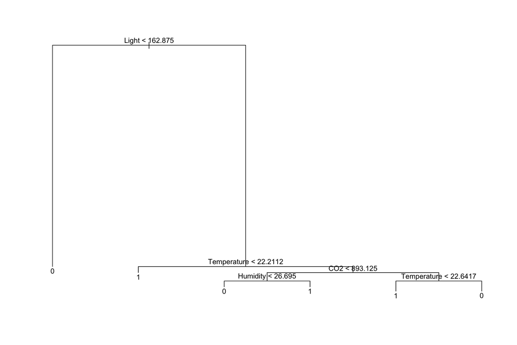

```r
plot(tree.training_set)
text(tree.training_set,pretty=0)
```

### (c) Train a random forests classifier and evaluate the predictive performance by reporting the classification accuracy obtained on the testing dataset. Define set.seed(1).

```r
library(randomForest)

training_set <- read.table('Room_Occupancy_Training_set.txt', header=TRUE, sep = ',')
testing_set <- read.table('Room_Occupancy_Testing_set.txt', header=TRUE, sep = ',')

training_set$Occupancy01 = as.factor(training_set$Occupancy)
testing_set$Occupancy01 = as.factor(testing_set$Occupancy)

training_set <- na.omit(training_set)
summary(training_set)
```

```
##   Temperature       Humidity         Light            CO2
##  Min.   :20.10   Min.   :18.96   Min.   :  0.0   Min.   : 426.0
##  1st Qu.:20.89   1st Qu.:21.82   1st Qu.:  0.0   1st Qu.: 448.0
##  Median :21.20   Median :25.00   Median :  0.0   Median : 485.5
##  Mean   :21.42   Mean   :24.22   Mean   :144.7   Mean   : 634.6
##  3rd Qu.:22.10   3rd Qu.:26.29   3rd Qu.:433.0   3rd Qu.: 845.8
##  Max.   :23.18   Max.   :28.50   Max.   :744.0   Max.   :1139.0
##  HumidityRatio        Occupancy      Occupancy01
##  Min.   :0.002824   Min.   :0.0000   0:1445
##  1st Qu.:0.003375   1st Qu.:0.0000   1: 555
##  Median :0.003905   Median :0.0000
##  Mean   :0.003836   Mean   :0.2775
##  3rd Qu.:0.004343   3rd Qu.:1.0000
##  Max.   :0.004817   Max.   :1.0000
```

```r
set.seed(1)

x_test <- testing_set[,-c(6,7)]
occupancy.test <- testing_set$Occupancy

bag.room <- randomForest(Occupancy ~ .-Occupancy01,
data = training_set,
mtry=7,
importance = TRUE)

print(bag.room)
```

```
##
## Call:
##  randomForest(formula = Occupancy ~ . - Occupancy01, data = training_set,      mtry = 7, importance = TRUE)
##                Type of random forest: regression
##                      Number of trees: 500
## No. of variables tried at each split: 5
##
##           Mean of squared residuals: 0.009616118
##                     % Var explained: 95.2
```

```r
bag.pred <- predict(bag.room, newdata = testing_set)
bag.pred.class <- ifelse(bag.pred <= 0.5, "0", "1")
print(mean(bag.pred.class!=occupancy.test))
```

```
## [1] 0.2533333
```

### (d) Output and analyse the feature importance obtained by the random forests classifier.

```r
importance(bag.room)
```

```
##                 %IncMSE IncNodePurity
## Temperature    38.27011     21.869114
## Humidity       24.51262      4.787274
## Light         144.60039    354.588530
## CO2            41.69777     13.870205
## HumidityRatio  19.09822      3.682720
```

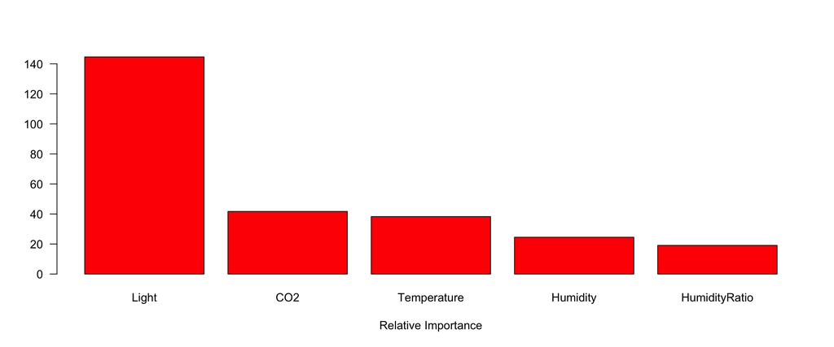

```r
barplot(sort(importance(bag.room)[,1], decreasing = TRUE),
xlab = "Relative Importance",
horiz = FALSE,
col = "red",
las=1 #The las argument will allow rotation of 90 degrees for labels
)
```

Light is the most important feature when predicting occupancy and Humidity Ratio is the least. We can see Humidity is also down the chain which is also why Humidity ratio is last. CO2 and temperature and very close to each other in terms of relative importance.

## 3. Predicting wine quality by using support vector machine classification algorithm.

### (a) Download the full wine quality training and testing datasets from Moodle, and use the training dataset to find out the optimal value of hyperparameter C for a linear kernel-based svm.

```r
library(e1071)

training_set <- read.table('Full_WineQuality_Training.txt', header=TRUE, sep = ',')
testing_set <- read.table('Full_WineQuality_Testing.txt', header=TRUE, sep = ',')

set.seed(1)

training_set$quality<- as.factor(training_set$quality)

tune.out<-tune(svm,quality~.,data=training_set,kernel="linear",ranges=list(cost=c(0.001,0.01,0.1,1,10,100)))

bestmod <- tune.out$best.model
summary(bestmod)
```

```
##
## Call:
## best.tune(method = svm, train.x = quality ~ ., data = training_set,
##     ranges = list(cost = c(0.001, 0.01, 0.1, 1, 10, 100)), kernel = "linear")
##
##
## Parameters:
##    SVM-Type:  C-classification
##  SVM-Kernel:  linear
##        cost:  10
##
## Number of Support Vectors:  1564
##
##  ( 780 784 )
##
##
## Number of Classes:  2
##
## Levels:
##  Bad Good
```

The optimal value for cost hyper parameter is 10.

### (b) Train a svm classifier by using the linear kernel and the corresponding optimal value of hyperparameter C, then make predictions on the testing dataset, report the classification accuracy.

```r
set.seed(1)
svmfit.train.C10 <- svm(quality ~ .,
data = training_set,
kernel = "linear",
cost = 10,
scale = FALSE)

summary(svmfit.train.C10)
```

```
##
## Call:
## svm(formula = quality ~ ., data = training_set, kernel = "linear",
##     cost = 10, scale = FALSE)
##
##
## Parameters:
##    SVM-Type:  C-classification
##  SVM-Kernel:  linear
##        cost:  10
##
## Number of Support Vectors:  1537
##
##  ( 769 768 )
##
##
## Number of Classes:  2
##
## Levels:
##  Bad Good
```

```r
y.pred.C10 <- predict(svmfit.train.C10, newdata = testing_set)

y_test <- as.factor(testing_set$quality)
mean(y.pred.C10 == y_test)
```

```
## [1] 0.6823529
```

There are 1537 support vectors, 769 from the class of y = -1 and 768 from the class of y = 1 The classification accuracy is 68.2%

### (c) Use the training dataset to find out the optimal values of hyperparameters C and γ for an RBF kernel-based svm.

```r
set.seed(1)
tune.out <- tune(svm, quality ~ ., data=training_set, kernel="radial",
ranges = list(cost=c(0.1,1,10,100),gamma=c(0.01,0.1,0.5, 1, 10, 100)))

summary(tune.out)
```

```
##
## Parameter tuning of 'svm':
##
## - sampling method: 10-fold cross validation
##
## - best parameters:
##  cost gamma
##    10   0.5
##
## - best performance: 0.1716912
##
## - Detailed performance results:
##     cost gamma     error dispersion
## 1    0.1 1e-02 0.2591912 0.02977966
## 2    1.0 1e-02 0.2367647 0.02500721
## 3   10.0 1e-02 0.2161765 0.02862510
## 4  100.0 1e-02 0.2110294 0.02408953
## 5    0.1 1e-01 0.2180147 0.02351217
## 6    1.0 1e-01 0.2036765 0.02138120
## 7   10.0 1e-01 0.1996324 0.02805543
## 8  100.0 1e-01 0.2007353 0.02548312
## 9    0.1 5e-01 0.2308824 0.03222830
## 10   1.0 5e-01 0.1805147 0.02958740
## 11  10.0 5e-01 0.1716912 0.02293010
## 12 100.0 5e-01 0.1768382 0.02410511
## 13   0.1 1e+00 0.3981618 0.06553910
## 14   1.0 1e+00 0.1761029 0.02613773
## 15  10.0 1e+00 0.1761029 0.02496213
## 16 100.0 1e+00 0.1764706 0.02679315
## 17   0.1 1e+01 0.4878676 0.03820897
## 18   1.0 1e+01 0.3220588 0.04689642
## 19  10.0 1e+01 0.3176471 0.04602364
## 20 100.0 1e+01 0.3176471 0.04602364
## 21   0.1 1e+02 0.4878676 0.03820897
## 22   1.0 1e+02 0.3507353 0.04288165
## 23  10.0 1e+02 0.3496324 0.04243276
## 24 100.0 1e+02 0.3496324 0.04243276
```

The optimal hyperparameter C 10 is and γ is 0.5

### (d) Train a svm classifier by using the RBF kernel and the corresponding optimal values of hyperparameters C and γ, then make predictions on the testing dataset, report the classification accuracy.

```r
rbffit.train <- svm(quality ~ .,
data = training_set,
kernel = "radial",
cost = 10,
gamme = 0.5,
scale = FALSE)

y.pred <- predict(rbffit.train, newdata = testing_set)

y_test <- as.factor(testing_set$quality)
mean(y.pred == y_test)
```

```
## [1] 0.7676471
```

The classification accuracy is 76.7% which is an improvement from the linear model which had an accuracy of 68.2%.

### (e) Train a logistic regression model. Then use the testing dataset to conduct an ROC curve analysis to compare the predictive performance of the trained logistic regression model and those two svm classifiers trained by using linear and RBF kernels respectively.

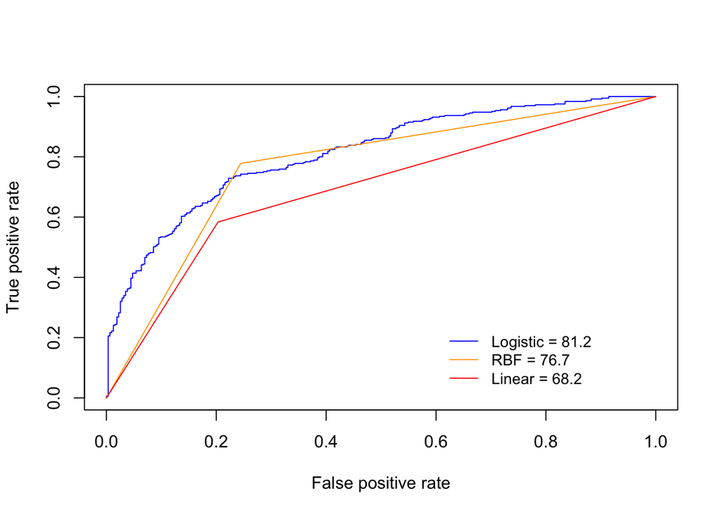

```r
library(caret)
library(ROCR)

log_reg <- glm(quality  ~ fixed.acidity+volatile.acidity+ citric.acid + residual.sugar+chlorides+free.sulfur.dioxide+total.sulfur.dioxide+ density+pH+sulphates+alcohol, data = training_set, family = binomial)

log_reg_pred <-predict(log_reg, testing_set, type='response')
pr_log_reg_pred <- prediction(log_reg_pred, testing_set$quality)
auroc_log_reg <-performance(pr_log_reg_pred, measure = "auc")


prf_trained_model_1 <- performance(pr_log_reg_pred, measure = "tpr", x.measure = "fpr")

pr.y.pred <- prediction(as.numeric(y.pred),testing_set$quality)
prf_trained_model_2 <- performance(pr.y.pred, measure = "tpr", x.measure = "fpr")

pr.y.pred.10 <- prediction(as.numeric(y.pred.C10),testing_set$quality)
prf_trained_model_3 <- performance(pr.y.pred.10, measure = "tpr", x.measure = "fpr")

plot(prf_trained_model_1, col="blue")
plot(prf_trained_model_2, col="orange", add=TRUE)
plot(prf_trained_model_3, col="red", add=TRUE)

legend(0.6,0.25, c(text=sprintf('Logistic = %s',round(auroc_log_reg@y.values[[1]]*100, digits=1)),
text=sprintf('RBF = %s',76.7),
text=sprintf('Linear = %s',68.2)),
lty=1, cex=0.9, col = c("blue", "orange", "red"), bty="n", y.intersp=1, inset=c(0.1,-0.15))
```

The AUROC value using the logistic regression is 81.2% which means the classification is more accurate through a logistic regression than svm. RBF classifier has a higher accuracy than Linear SVM.

## 4. Hierarchical Clustering

Consider the US Arrests data. We will now perform hierarchical clustering on the states.

### (a) Using hierarchical clustering with complete linkage and Euclidean distance, cluster the states.

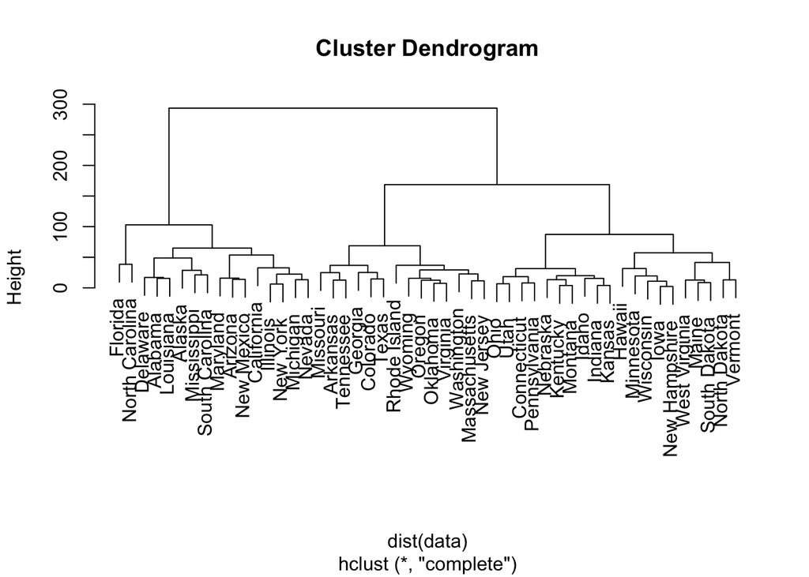

```r
data <- USArrests
hc <- hclust(dist(data),method="complete")
plot(hc)
```

### (b) Cut the dendrogram at a height that results in three distinct clusters. Which states belong to which clusters?

```r
cutree(hc, k = 3)
```

```
##        Alabama         Alaska        Arizona       Arkansas     California
##              1              1              1              2              1
##       Colorado    Connecticut       Delaware        Florida        Georgia
##              2              3              1              1              2
##         Hawaii          Idaho       Illinois        Indiana           Iowa
##              3              3              1              3              3
##         Kansas       Kentucky      Louisiana          Maine       Maryland
##              3              3              1              3              1
##  Massachusetts       Michigan      Minnesota    Mississippi       Missouri
##              2              1              3              1              2
##        Montana       Nebraska         Nevada  New Hampshire     New Jersey
##              3              3              1              3              2
##     New Mexico       New York North Carolina   North Dakota           Ohio
##              1              1              1              3              3
##       Oklahoma         Oregon   Pennsylvania   Rhode Island South Carolina
##              2              2              3              2              1
##   South Dakota      Tennessee          Texas           Utah        Vermont
##              3              2              2              3              3
##       Virginia     Washington  West Virginia      Wisconsin        Wyoming
##              2              2              3              3              2
```

```r
sort(hc$height)
```

```
##  [1]   2.291288   3.834058   3.929377   6.236986   6.637771   7.355270
##  [7]   8.027453   8.537564  10.860018  11.456439  12.424975  12.614278
## [13]  12.775367  13.044922  13.297368  13.349157  13.896043  14.501034
## [19]  15.407790  15.454449  15.630099  15.890249  16.976749  18.264994
## [25]  19.437592  19.904271  21.167192  22.366046  22.766642  24.894377
## [31]  25.093027  28.635118  29.250641  31.477135  31.620405  32.718802
## [37]  36.734861  36.847931  38.527912  41.487950  48.725148  53.593376
## [43]  57.271022  64.993615  68.762272  87.326342 102.861557 168.611417
## [49] 293.622751
```

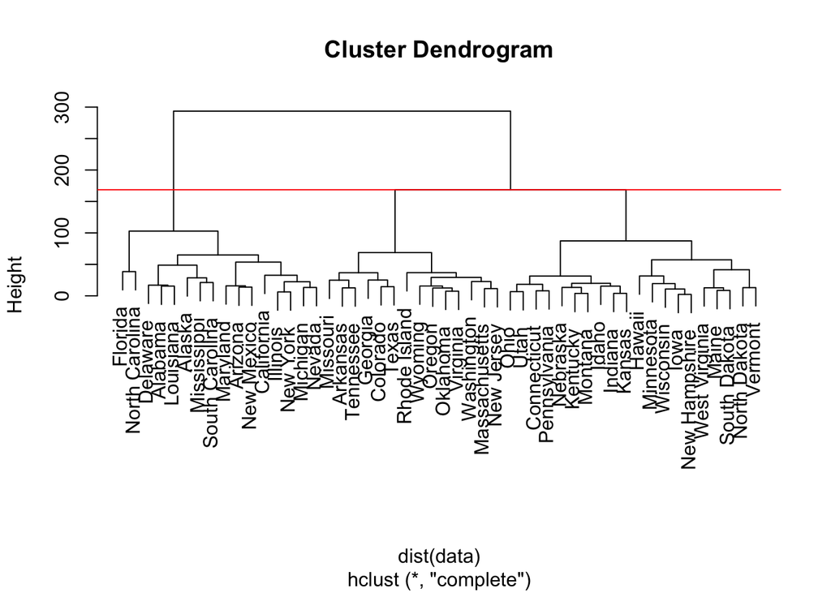

```r
plot(hc)
abline(h=168.6,col="red")
```

If we cut the dendrogram at 168.6 height, we get three distinct clusters and the states in each cluster are shown above.

### (c) Hierarchically cluster the states using complete linkage and Euclidean distance, after scaling the variables to have standard deviation one.

```r
library(matrixStats)
data_scaled <- scale(data)

# check that we get sd of 1
apply(data_scaled, 2, sd)
```

```
##   Murder  Assault UrbanPop     Rape
##        1        1        1        1
```

```r
hc_scaled <- hclust(dist(data_scaled),method="complete")
sort(hc_scaled$height)
```

```
##  [1] 0.2058539 0.3502188 0.4287712 0.4940832 0.5303259 0.5353893 0.5935343
##  [8] 0.6457158 0.7038309 0.7108812 0.7389936 0.7722224 0.7781298 0.7865674
## [15] 0.7977642 0.8286936 0.8412900 0.8457697 0.9824857 0.9971035 1.0122252
## [22] 1.0354597 1.0709720 1.0800988 1.0918624 1.1314351 1.1826891 1.1968261
## [29] 1.2117356 1.2502752 1.2716808 1.3329504 1.3988595 1.4668378 1.6230495
## [36] 1.6448574 1.6585736 1.8537984 1.8649801 2.2630242 2.2952287 2.3374653
## [43] 2.4458600 2.4748807 3.0883430 3.2554326 4.4005416 4.4200736 6.0766416
```

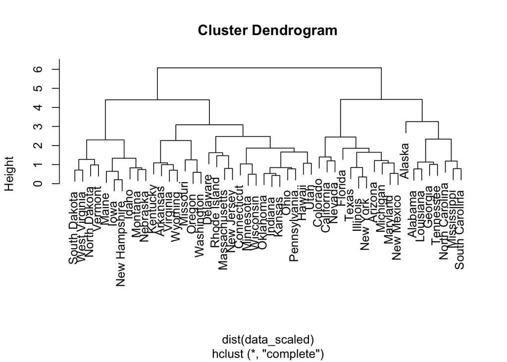

```r
plot(hc_scaled)
```

### (d) What effect does scaling the variables have on the hierarchical clustering obtained? In your opinion, should the variables be scaled before the inter-observation dissimilarities are computed? Provide a justification for your answer.

```r
table(cutree(hc, 3), cutree(hc_scaled, 3))
```

```
##
##      1  2  3
##   1  6  9  1
##   2  2  2 10
##   3  0  0 20
```

Scaling created more clusters at a height closer to the maximum, this means the clustering increases the dissimilarity. If we were to pick a height to create three clusters, it would be more difficult when the data is scaled, as there are 4 clusters forming at a similar height(around 4.4). I think the variables should be scaled before as the units are different such as Urban Pop and Murder. This will help to standardize the data set improving our clustering.

## 5. PCA and K-Means Clustering

In this problem, you will generate simulated data, and then perform PCA and K-means clustering on the data.

### (a) Generate a simulated data set with 20 observations in each of three classes (i.e. 60 observations total), and 50 variables.

Hint: There are a number of functions in R that you can use to generate data. One example is the rnorm() function; runif() is another option. Be sure to add a mean shift to the observations in each class so that there are three distinct classes.

```r
set.seed(1)
class1 <- matrix(rnorm(20*50, mean = 5), ncol = 50)
class2 <- matrix(rnorm(20*50,  mean = 10), ncol = 50)
class3 <- matrix(rnorm(20*50, mean = 20), ncol = 50)

data <- cbind(rbind(class1, class2, class3),class = as.factor(c( rep(1,20), rep(2,20), rep(3,20) )))

data <- data.frame(data)

dim(data)
```

```
## [1] 60 51
```

### (b) Perform PCA on the 60 observations and plot the first two principal components’ eigenvector. Use a different color to indicate the observations in each of the three classes. If the three classes appear separated in this plot, then continue on to part (c). If not, then return to part (a) and modify the simulation so that there is greater separation between the three classes. Do not continue to part (c) until the three classes show at least some separation in the first two principal component eigenvectors.

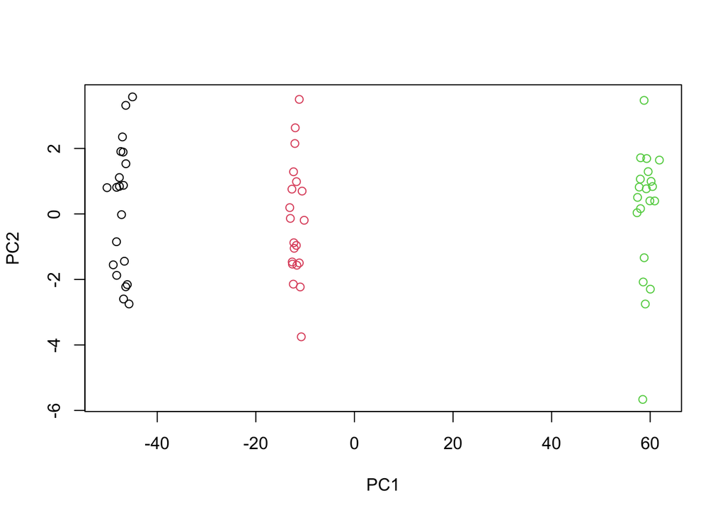

```r
pca = prcomp(data, scale=FALSE)

plot(pca$x[,1:2], col = c(rep(1, 20), rep(2, 20), rep(3, 20)))
```

The three classes are seperate as displayed in the graph.

### (c) Perform K-means clustering of the observations with K = 3. How well do the clusters that you obtained in K-means clustering compare to the true class labels? Hint: You can use the table() function in R to compare the true class labels to the class labels obtained by clustering. Be careful how you interpret the results: K-means clustering will arbitrarily number the clusters, so you cannot simply check whether the true class labels and clustering labels are the same.

```r
set.seed(1)
km = kmeans(data,3,nstart= 20)

table(km$cluster,c(rep(1, 20), rep(2, 20), rep(3, 20)),dnn=c("Clusters","Class Labels"))
```

```
##         Class Labels
## Clusters  1  2  3
##        1  0  0 20
##        2 20  0  0
##        3  0 20  0
```

Kmeans splits the number of rows into even clusters. Cluster 1,2 and 3 all have 20 observations.

### (d) Perform K-means clustering with K = 2. Describe your results.

```r
set.seed(1)
km = kmeans(data,2,nstart= 20)

table(km$cluster,c(rep(1, 20), rep(2, 20), rep(3, 20)),dnn=c("Clusters","Class Labels"))
```

```
##         Class Labels
## Clusters  1  2  3
##        1  0  0 20
##        2 20 20  0
```

Cluster 2 has 40 of the rows whereas cluster 1 has 20 now. The majority of the observations are in cluster 2.

### (e) Now perform K-means clustering with K = 4, and describe your results.

```r
set.seed(1)
km = kmeans(data,4,nstart= 20)

table(km$cluster,c(rep(1, 20), rep(2, 20), rep(3, 20)),dnn=c("Clusters","Class Labels"))
```

```
##         Class Labels
## Clusters  1  2  3
##        1  0  0 20
##        2 11  0  0
##        3  0 20  0
##        4  9  0  0
```

There is not a majority cluster. Cluster 1 and 3 share equal observations at 20, while cluster 2 and 4 have 11 and 9 respectively. Compared to the clustering with 3 clusters, we can see that some of Cluster 2 has been moved to Cluster 4. We would have to see the actual clustered data points to see which have moved, since the assigned cluster to the class labels is random.

### (f) Now perform K-means clustering with K = 3 on the first two principal components, rather than on the raw data. That is, perform K-means clustering on the 60 × 2 matrix of which the first column is the first principal component’s corresponding eigenvector, and the second column is the second principal component’s corresponding eigenvector. Comment on the results.

```r
set.seed(1)
km_pca <- kmeans(pca$x[,1:2],3, nstart=20)

table(km_pca$cluster,c(rep(1, 20), rep(2, 20), rep(3, 20)),dnn=c("Clusters","Class Labels"))
```

```
##         Class Labels
## Clusters  1  2  3
##        1  0  0 20
##        2 20  0  0
##        3  0 20  0
```

We get the same results as the first instance of clustering where the observations are clustered perfectly.

### (g) Using the scale() function, perform K-means clustering with K = 3 on the data after scaling each variable to have standard deviation one. How do these results compare to the true class labels? Will the scaling affect the clustering?

```r
scaled_data = scale(data)
km = kmeans(scaled_data, 3, nstart=20)
table(km$cluster,c(rep(1, 20), rep(2, 20), rep(3, 20)),dnn=c("Clusters","Class Labels"))
```

```
##         Class Labels
## Clusters  1  2  3
##        1 20  0  0
##        2  0  0 20
##        3  0 20  0
```

Scaling the data perfectly splits the Class labels into the 3 clusters, similar to the kmeans without scaling. It is sometimes possible that scaling will affect the clustering as it changes the relationship/distance between the data points as it is not the same raw data anymore.